# Data 605 Discussion Week-12

## —————————————————————————

### **Student Name :** Sachid Deshmukh

### **Date :** 04/18/2019

- > [GitHub Location for rmd file](https://github.com/mlforsachid/MSDSQ2Data605/blob/master/Week12/Discussion/SachidVijay.Deshmukh60.Rmd)
- > [RPubs location of published file](http://rpubs.com/sachid/Data605Week12Disc)

## —————————————————————————

**In this example we will use built in cars dataset to build multiple regression model**

**Aim is to predict car mileage using car displacement, horsepower, drat and weight**

**1] Data Analysis**

```r
head(mtcars)
```

```
##                    mpg cyl disp  hp drat    wt  qsec vs am gear carb
## Mazda RX4         21.0   6  160 110 3.90 2.620 16.46  0  1    4    4
## Mazda RX4 Wag     21.0   6  160 110 3.90 2.875 17.02  0  1    4    4
## Datsun 710        22.8   4  108  93 3.85 2.320 18.61  1  1    4    1
## Hornet 4 Drive    21.4   6  258 110 3.08 3.215 19.44  1  0    3    1
## Hornet Sportabout 18.7   8  360 175 3.15 3.440 17.02  0  0    3    2
## Valiant           18.1   6  225 105 2.76 3.460 20.22  1  0    3    1
```

```r
str(mtcars)
```

```
## 'data.frame':    32 obs. of  11 variables:
##  $ mpg : num  21 21 22.8 21.4 18.7 18.1 14.3 24.4 22.8 19.2 ...
##  $ cyl : num  6 6 4 6 8 6 8 4 4 6 ...
##  $ disp: num  160 160 108 258 360 ...
##  $ hp  : num  110 110 93 110 175 105 245 62 95 123 ...
##  $ drat: num  3.9 3.9 3.85 3.08 3.15 2.76 3.21 3.69 3.92 3.92 ...
##  $ wt  : num  2.62 2.88 2.32 3.21 3.44 ...
##  $ qsec: num  16.5 17 18.6 19.4 17 ...
##  $ vs  : num  0 0 1 1 0 1 0 1 1 1 ...
##  $ am  : num  1 1 1 0 0 0 0 0 0 0 ...
##  $ gear: num  4 4 4 3 3 3 3 4 4 4 ...
##  $ carb: num  4 4 1 1 2 1 4 2 2 4 ...
```

```r
attach(mtcars)
```

**2] Build Model**

```r
model <- mpg~disp + hp + drat + wt
fit <- lm(model, mtcars)
fit
```

```
##
## Call:
## lm(formula = model, data = mtcars)
##
## Coefficients:
## (Intercept)         disp           hp         drat           wt
##   29.148738     0.003815    -0.034784     1.768049    -3.479668
```

**3] Model Summary.**

```r
summary(fit)
```

```
##
## Call:
## lm(formula = model, data = mtcars)
##
## Residuals:
##     Min      1Q  Median      3Q     Max
## -3.5077 -1.9052 -0.5057  0.9821  5.6883
##
## Coefficients:
##              Estimate Std. Error t value Pr(>|t|)
## (Intercept) 29.148738   6.293588   4.631  8.2e-05 ***
## disp         0.003815   0.010805   0.353  0.72675
## hp          -0.034784   0.011597  -2.999  0.00576 **
## drat         1.768049   1.319779   1.340  0.19153
## wt          -3.479668   1.078371  -3.227  0.00327 **
## ---
## Signif. codes:  0 '***' 0.001 '**' 0.01 '*' 0.05 '.' 0.1 ' ' 1
##
## Residual standard error: 2.602 on 27 degrees of freedom
## Multiple R-squared:  0.8376, Adjusted R-squared:  0.8136
## F-statistic: 34.82 on 4 and 27 DF,  p-value: 2.704e-10
```

**From the model summary we can conclude that**

**1. Horsepower and Weight are the strong predictor of mileage**

**2. Displacement and drat are not helping in predicting car mileage**

**3. Negative coefficient for horsepower and weight indicates that mileage increases as weight and horsepower decreases and vice versa**

**Residual Analysis**

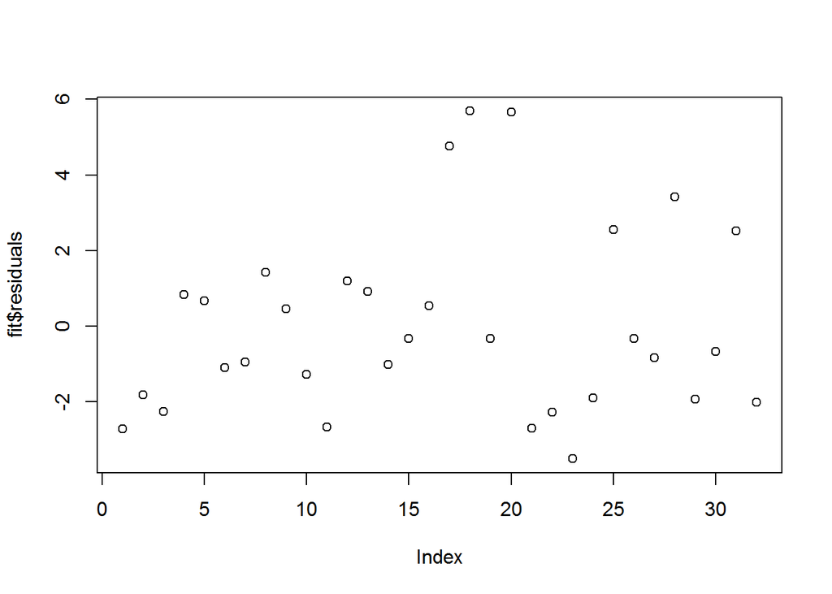

```r
plot(fit$residuals)
```

**Residuals are y axis imbalance indicating some outliers in the data**

**Residuals show some non-linear pattern indicating relationship of mileage and predictor variables is not strictly linear**

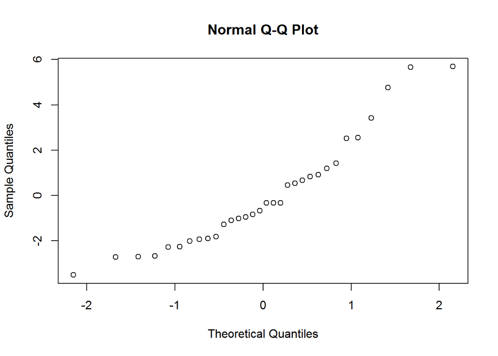

```r
qqnorm(fit$residuals)
```

**Residuals are not normally distributed indicating weight and horsepower are not the only predictor for mileage. We need to add some more predictor for good fit of the model**